# TITLE by Anfeng Yu

LoanCurrentDaysDelinquent has a unusual distribution, because most data are 0.

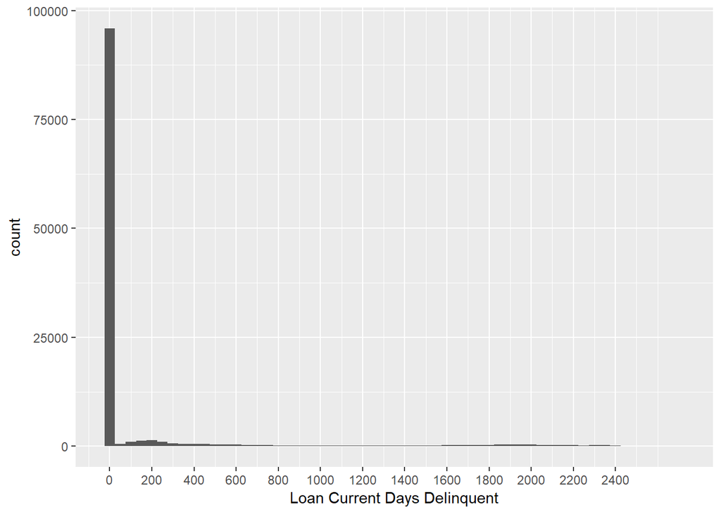

By this graph, alomost all customers’ LoanCurrentDaysDelinquent is 0, for further investigation, I choose to use data with LoanData$LoanCurrentDaysDelinquent > 0.

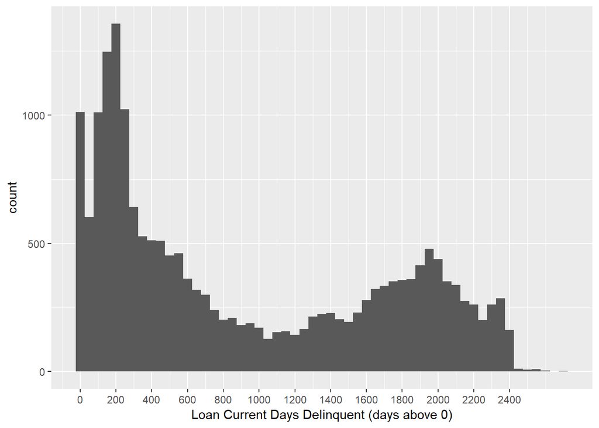

By this graph,I can see that the distribution of LoanCurrentDaysDelinquent above 0 is like two normal distributions’ combination, one with mean 200, another with mean about 1950.

# Univariate Analysis

### What is the structure of your dataset?

The prosperLoanData is a set of each customers’ loan and personal information data.For each customer, this data set has his/her loan amount and rate, salary and job, also estimated effictive yield(earned money).

### What is/are the main feature(s) of interest in your dataset?

By my exploration, I think main feature is estimatedEffctiveYield, because this feature reveal by this customer how much interest we company can make.

### What other features in the dataset do you think will help support your

First,IncomeRange, StatedMonthlyIncome and LoanOriginalAmount, these features help me to figure out if this person has the ability to pay his loan. Second OnTimeProsperPayments, creditGrade can show if this customer can usually pay his loan.

### Did you create any new variables from existing variables in the dataset?

No.

### Of the features you investigated, were there any unusual distributions? Did

# Bivariate Plots Section

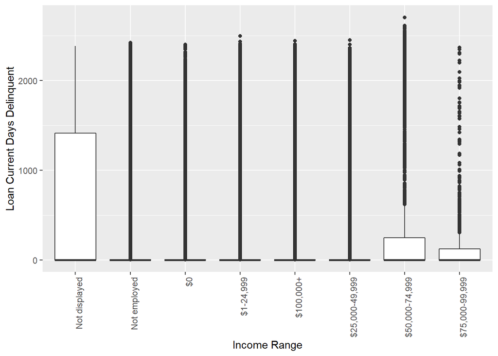

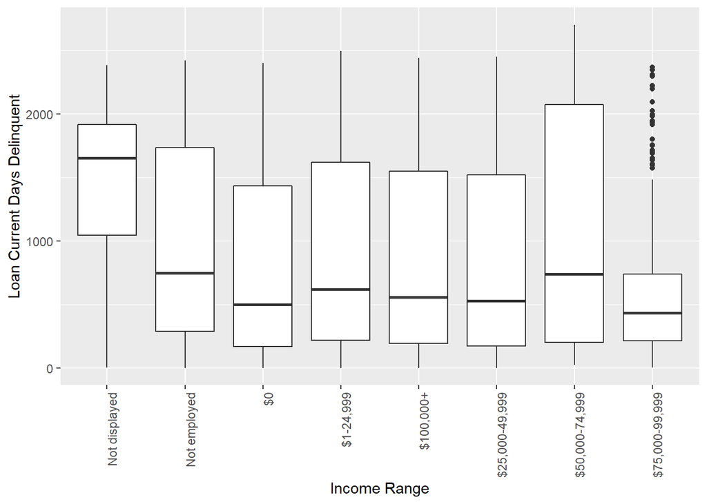

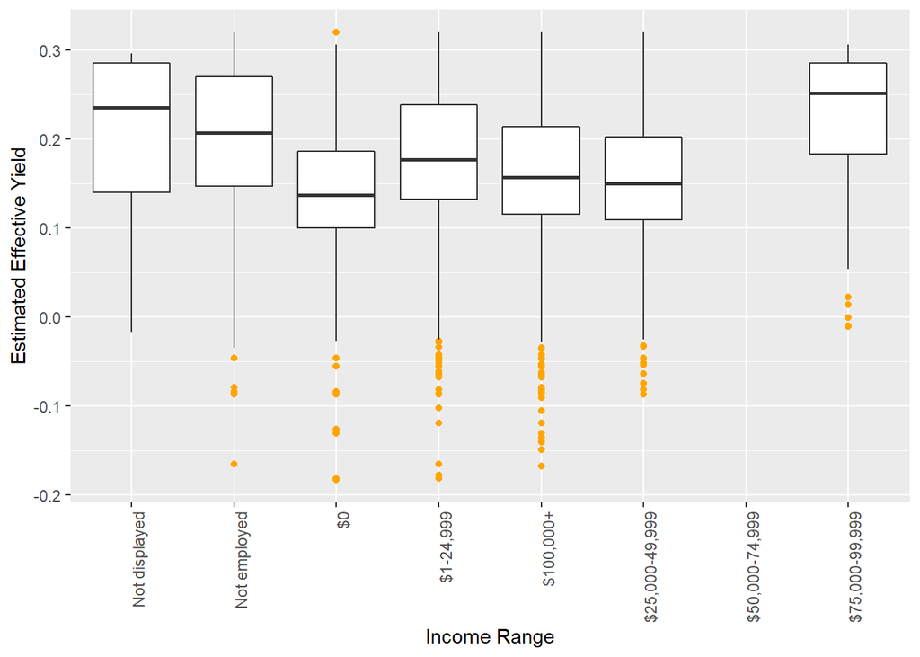

It seems there is no strong relationship between IncomeRange and EstimatedEffectiveYield.

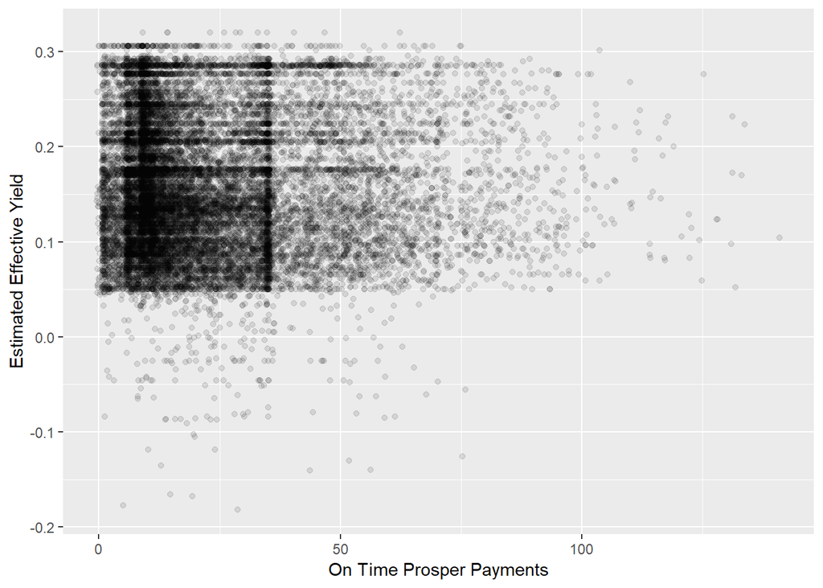

By this graph, it is hard to see if there is any strong relationship between OnTimeProsperPayments and EstimatedEffectiveYield.

```
## [1] -0.01120913
```

By computing corelationship, we can see there is no siginificant relationship between EstimatedEffectiveYield and OnTimeProsperPayments.

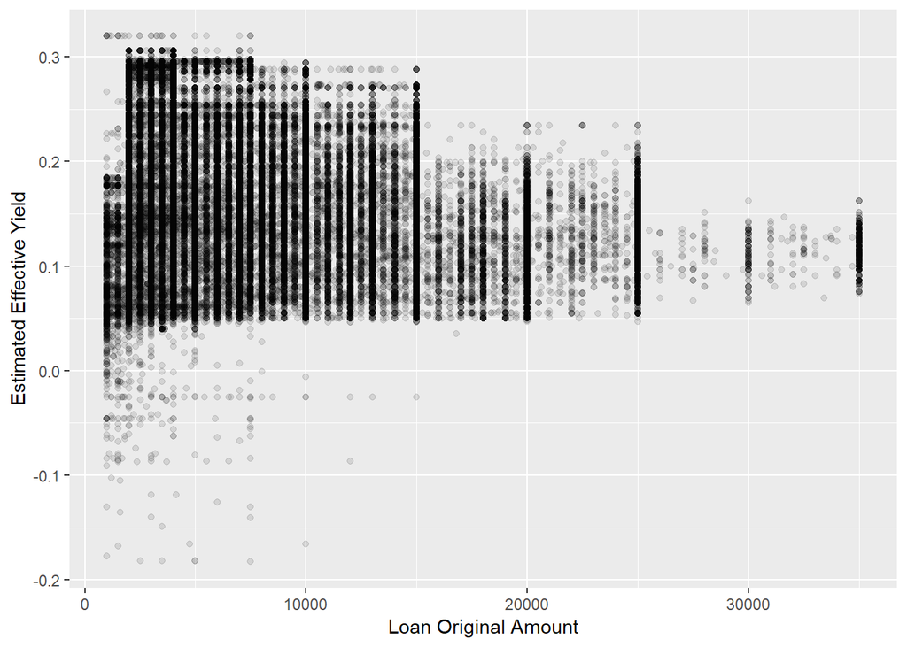

We can see there may be some relationship between LoanOriginalAmount and EstimatedEffectiveYield.

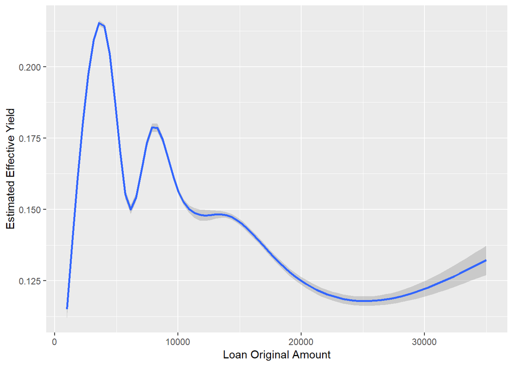

We can see, when LoanOriginalAmount is below 15000, the EstimatedEffectiveYield is relatively higher.

```
## [1] -0.3272657
```

The corelation between these two features are also proof of this.

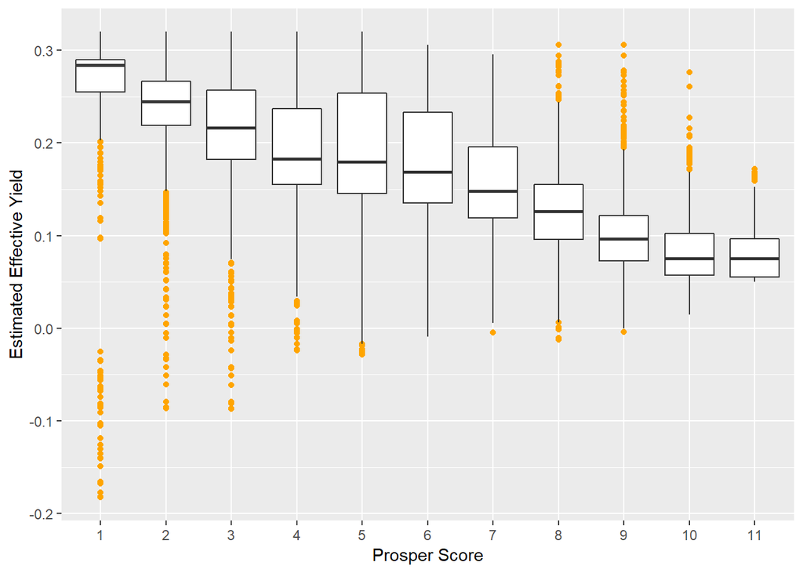

Also, there is a strong relationship between ProsperScore and EstimatedEffectiveYield. The higher ProsperScore is, the less EstimatedEffectiveYield is.

```
## [1] -0.6320034
```

The corelation also proves this.

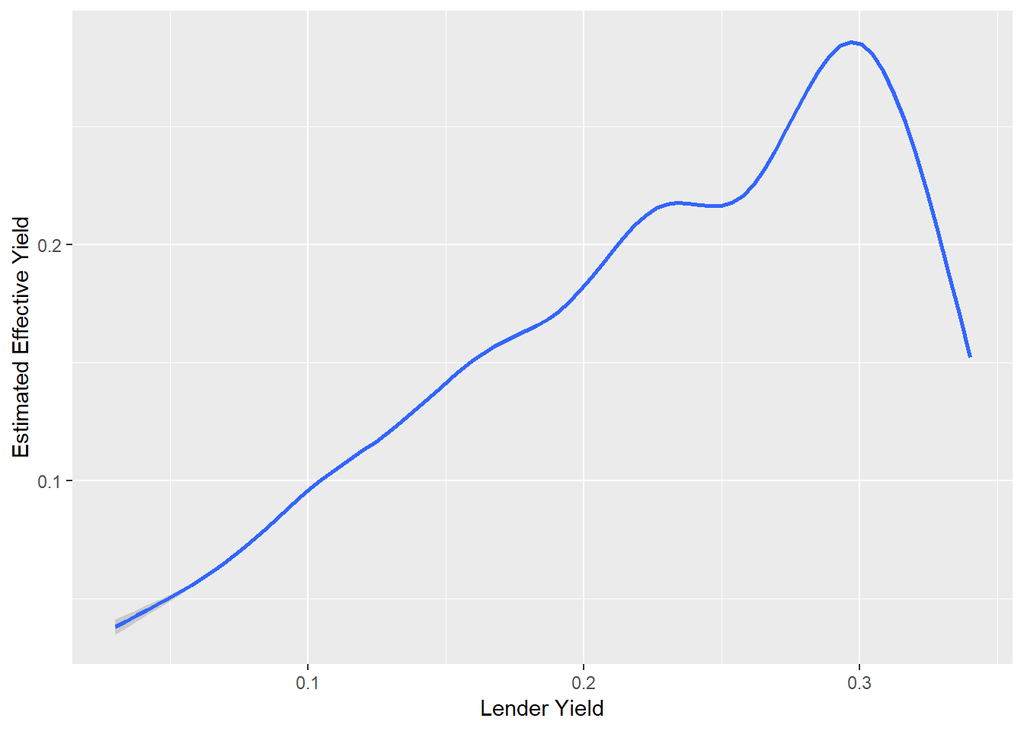

There is a very strong positive ratio relationship between LenderYield and EstimatedEffectiveYield, however when LenderYield is higher than 0.3, EstimatedEffectiveYield goes downwards.

```
## [1] 0.8953425
```

The corelation also proves this.

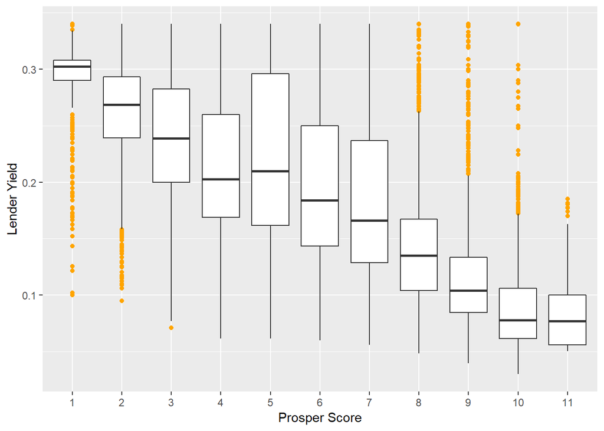

The relationship is even more obvious for LenderYield and ProsperScore.

```
## [1] -0.6497835
```

The corelation also proves this.

# Bivariate Analysis

### Talk about some of the relationships you observed in this part of the

For IncomeRange in $50,000 ~ $74,999, there is no data for EstimatedEffectiveYield.

### What was the strongest relationship you found?

There is a very strong positive ratio relationship between LenderYield and EstimatedEffectiveYield, however when LenderYield is higher than 0.3, EstimatedEffectiveYield goes downwards.

# Multivariate Plots Section

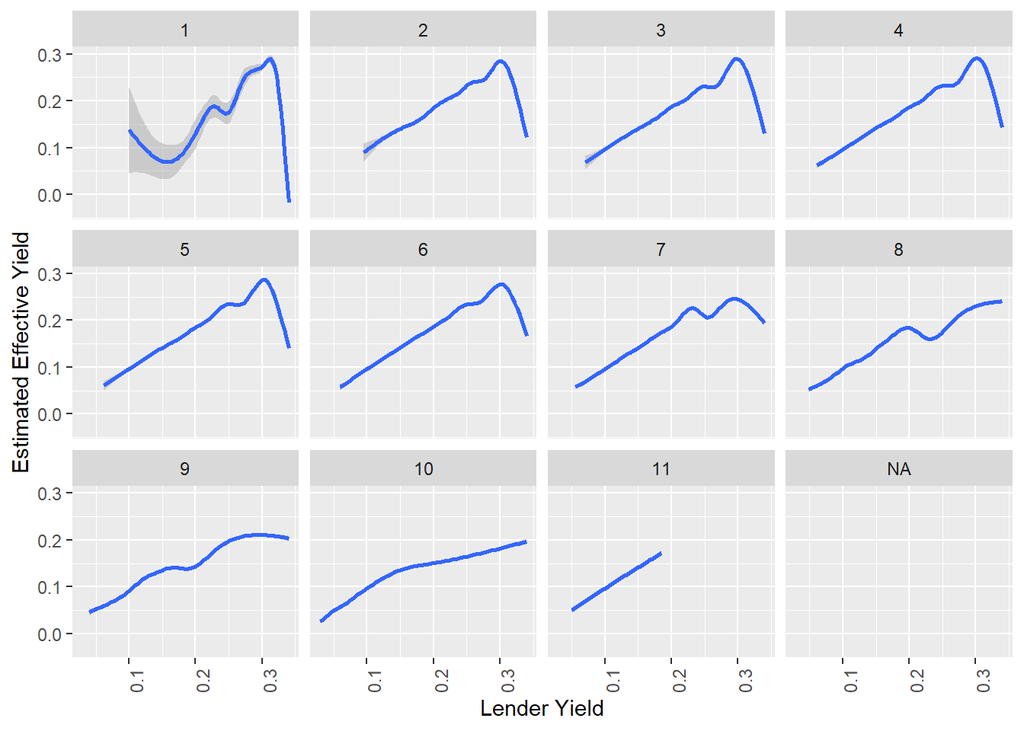

These plots(x is LenderYield, y is EstimatedEffectiveYield, faceted by ProsperScore) clearly show that, generally LenderYield has a positive ratio relationship with EstimatedEffectiveYield, and EstimatedEffectiveYield will decrease a little with ProsperScore’s increasing.

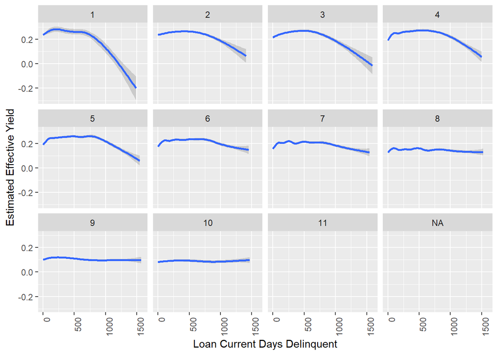

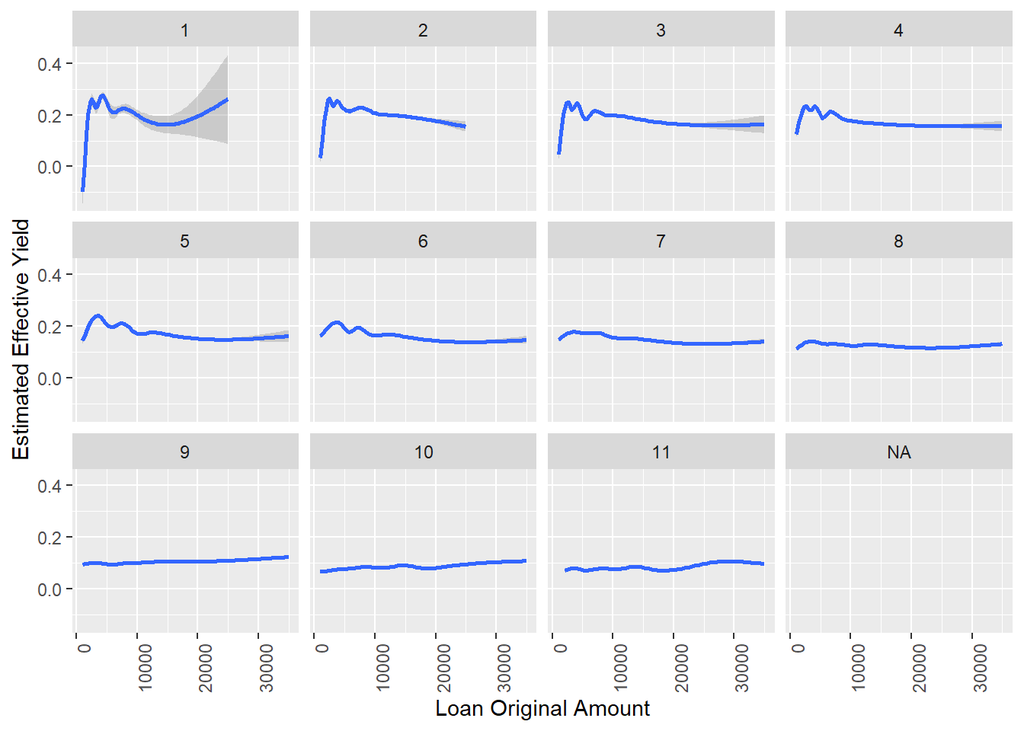

By this graph, we can see, with higher loan original amount, the estimated effective yield is relatively low, and with higher prosper score, the estimated effective yield will become lower.

# Multivariate Analysis

### Talk about some of the relationships you observed in this part of the

These plots(x is LenderYield, y is EstimatedEffectiveYield, faceted by ProsperScore) clearly show that, generally LenderYield has a positive ratio relationship with EstimatedEffectiveYield, and EstimatedEffectiveYield will decrease a little with ProsperScore’s increasing.

### OPTIONAL: Did you create any models with your dataset? Discuss the

# Final Plots and Summary

### Plot One

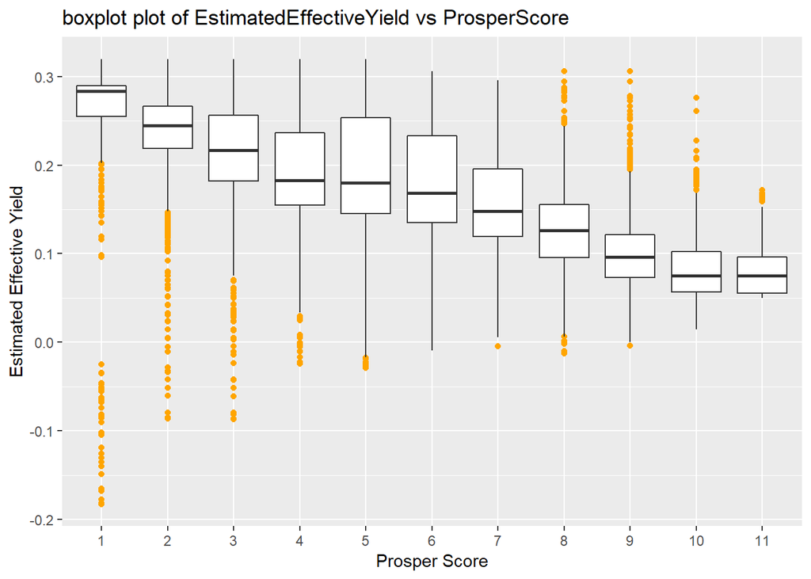

### Description One

there is a strong relationship between ProsperScore and EstimatedEffectiveYield. The higher ProsperScore is, the less EstimatedEffectiveYield is.

### Plot Two

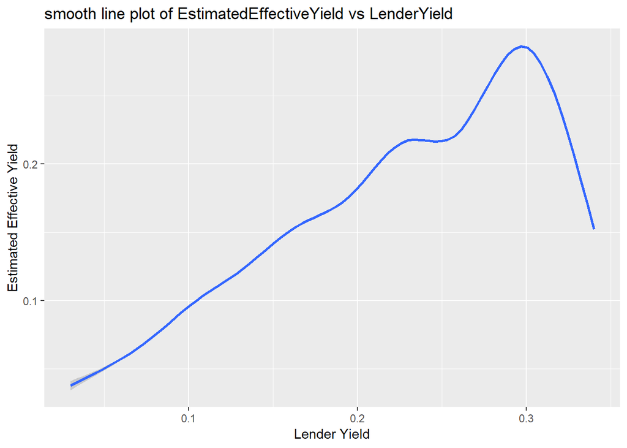

### Description Two

There is a very strong positive ratio relationship between LenderYield and EstimatedEffectiveYield, however when LenderYield is higher than 0.3, EstimatedEffectiveYield goes downwards.

### Plot Three

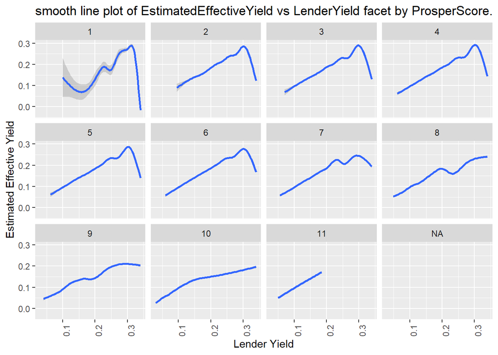

### Description Three

These plots(x is LenderYield, y is EstimatedEffectiveYield, faceted by ProsperScore) clearly show that, generally LenderYield has a positive ratio relationship with EstimatedEffectiveYield, and EstimatedEffectiveYield will decrease a little with ProsperScore’s increasing.

# Reflection

For this project, my most siginificant obstacle is to find what is the main feature. Finally I decided EstimatedEffectiveYield as my main feature because it is related with profit the bank can earn for each customer. However, there still are some other features very important, for example, Loan Current Days Delinquent, which may show if this customer can pay his/her credit or not.

So, for future’s further investigation, I would like to explore other features from other perspective, and at last make a fine predictive model to decide should the bank loan money to some customer or not.